# Risk Factor Analysis

## Outcome Variable

**Outcome Variable:** wast_rec90d

## Predictor Variables

**Intervention Variable:** vagbrth

**Adjustment Set:**

- arm
- sex
- W_mage
- meducyrs
- feducyrs
- hhwealth_quart
- hfoodsec
- W_mhtcm
- W_nrooms
- W_nchldlt5
- brthmon
- W_parity
- impfloor
- impsan
- safeh20
- delta_W_mage
- delta_meducyrs
- delta_feducyrs
- delta_hhwealth_quart
- delta_hfoodsec
- delta_W_mhtcm
- delta_W_nrooms
- delta_W_nchldlt5
- delta_brthmon
- delta_W_parity
- delta_impfloor
- delta_impsan
- delta_safeh20

## Stratifying Variables

The analysis was stratified on these variable(s):

- agecat
- studyid
- country

## Data Summary

| agecat | studyid | country | vagbrth | wast_rec90d | n_cell | n |
| --- | --- | --- | --- | --- | --- | --- |
| 0-24 months | ki1000108-CMC-V-BCS-2002 | INDIA | 0 | 0 | 11 | 326 |
| 0-24 months | ki1000108-CMC-V-BCS-2002 | INDIA | 0 | 1 | 9 | 326 |
| 0-24 months | ki1000108-CMC-V-BCS-2002 | INDIA | 1 | 0 | 109 | 326 |
| 0-24 months | ki1000108-CMC-V-BCS-2002 | INDIA | 1 | 1 | 197 | 326 |
| 0-24 months | ki1000108-IRC | INDIA | 0 | 0 | 24 | 395 |
| 0-24 months | ki1000108-IRC | INDIA | 0 | 1 | 39 | 395 |
| 0-24 months | ki1000108-IRC | INDIA | 1 | 0 | 138 | 395 |
| 0-24 months | ki1000108-IRC | INDIA | 1 | 1 | 194 | 395 |
| 0-24 months | ki1017093b-PROVIDE | BANGLADESH | 0 | 0 | 26 | 307 |
| 0-24 months | ki1017093b-PROVIDE | BANGLADESH | 0 | 1 | 43 | 307 |
| 0-24 months | ki1017093b-PROVIDE | BANGLADESH | 1 | 0 | 102 | 307 |
| 0-24 months | ki1017093b-PROVIDE | BANGLADESH | 1 | 1 | 136 | 307 |
| 0-24 months | ki1017093c-NIH-Crypto | BANGLADESH | 0 | 0 | 18 | 190 |
| 0-24 months | ki1017093c-NIH-Crypto | BANGLADESH | 0 | 1 | 43 | 190 |
| 0-24 months | ki1017093c-NIH-Crypto | BANGLADESH | 1 | 0 | 58 | 190 |
| 0-24 months | ki1017093c-NIH-Crypto | BANGLADESH | 1 | 1 | 71 | 190 |
| 0-24 months | ki1066203-TanzaniaChild2 | TANZANIA, UNITED REPUBLIC OF | 0 | 0 | 24 | 705 |
| 0-24 months | ki1066203-TanzaniaChild2 | TANZANIA, UNITED REPUBLIC OF | 0 | 1 | 32 | 705 |
| 0-24 months | ki1066203-TanzaniaChild2 | TANZANIA, UNITED REPUBLIC OF | 1 | 0 | 240 | 705 |
| 0-24 months | ki1066203-TanzaniaChild2 | TANZANIA, UNITED REPUBLIC OF | 1 | 1 | 409 | 705 |
| 0-24 months | ki1119695-PROBIT | BELARUS | 0 | 0 | 68 | 4431 |
| 0-24 months | ki1119695-PROBIT | BELARUS | 0 | 1 | 391 | 4431 |
| 0-24 months | ki1119695-PROBIT | BELARUS | 1 | 0 | 547 | 4431 |
| 0-24 months | ki1119695-PROBIT | BELARUS | 1 | 1 | 3425 | 4431 |
| 0-24 months | ki1126311-ZVITAMBO | ZIMBABWE | 0 | 0 | 119 | 3543 |
| 0-24 months | ki1126311-ZVITAMBO | ZIMBABWE | 0 | 1 | 182 | 3543 |
| 0-24 months | ki1126311-ZVITAMBO | ZIMBABWE | 1 | 0 | 1494 | 3543 |
| 0-24 months | ki1126311-ZVITAMBO | ZIMBABWE | 1 | 1 | 1748 | 3543 |
| 0-24 months | kiGH5241-JiVitA-3 | BANGLADESH | 0 | 0 | 412 | 15099 |
| 0-24 months | kiGH5241-JiVitA-3 | BANGLADESH | 0 | 1 | 482 | 15099 |

[output cut: 78 more lines]

The following strata were considered:

- agecat: 0-24 months, studyid: ki1000108-CMC-V-BCS-2002, country: INDIA
- agecat: 0-24 months, studyid: ki1000108-IRC, country: INDIA
- agecat: 0-24 months, studyid: ki1017093b-PROVIDE, country: BANGLADESH
- agecat: 0-24 months, studyid: ki1017093c-NIH-Crypto, country: BANGLADESH
- agecat: 0-24 months, studyid: ki1066203-TanzaniaChild2, country: TANZANIA, UNITED REPUBLIC OF
- agecat: 0-24 months, studyid: ki1119695-PROBIT, country: BELARUS
- agecat: 0-24 months, studyid: ki1126311-ZVITAMBO, country: ZIMBABWE
- agecat: 0-24 months, studyid: kiGH5241-JiVitA-3, country: BANGLADESH
- agecat: 0-24 months, studyid: kiGH5241-JiVitA-4, country: BANGLADESH
- agecat: 0-6 months, studyid: ki1000108-CMC-V-BCS-2002, country: INDIA
- agecat: 0-6 months, studyid: ki1000108-IRC, country: INDIA
- agecat: 0-6 months, studyid: ki1017093b-PROVIDE, country: BANGLADESH
- agecat: 0-6 months, studyid: ki1017093c-NIH-Crypto, country: BANGLADESH
- agecat: 0-6 months, studyid: ki1066203-TanzaniaChild2, country: TANZANIA, UNITED REPUBLIC OF
- agecat: 0-6 months, studyid: ki1119695-PROBIT, country: BELARUS
- agecat: 0-6 months, studyid: ki1126311-ZVITAMBO, country: ZIMBABWE
- agecat: 0-6 months, studyid: kiGH5241-JiVitA-3, country: BANGLADESH
- agecat: 0-6 months, studyid: kiGH5241-JiVitA-4, country: BANGLADESH
- agecat: 6-24 months, studyid: ki1000108-CMC-V-BCS-2002, country: INDIA
- agecat: 6-24 months, studyid: ki1000108-IRC, country: INDIA
- agecat: 6-24 months, studyid: ki1017093b-PROVIDE, country: BANGLADESH
- agecat: 6-24 months, studyid: ki1017093c-NIH-Crypto, country: BANGLADESH
- agecat: 6-24 months, studyid: ki1066203-TanzaniaChild2, country: TANZANIA, UNITED REPUBLIC OF
- agecat: 6-24 months, studyid: ki1119695-PROBIT, country: BELARUS
- agecat: 6-24 months, studyid: ki1126311-ZVITAMBO, country: ZIMBABWE
- agecat: 6-24 months, studyid: kiGH5241-JiVitA-3, country: BANGLADESH
- agecat: 6-24 months, studyid: kiGH5241-JiVitA-4, country: BANGLADESH

### Dropped Strata

Some strata were dropped due to rare outcomes:

- agecat: 0-6 months, studyid: ki1017093c-NIH-Crypto, country: BANGLADESH
- agecat: 6-24 months, studyid: ki1000108-CMC-V-BCS-2002, country: INDIA
- agecat: 6-24 months, studyid: ki1017093b-PROVIDE, country: BANGLADESH
- agecat: 6-24 months, studyid: ki1119695-PROBIT, country: BELARUS
- agecat: 6-24 months, studyid: kiGH5241-JiVitA-3, country: BANGLADESH

## Methods Detail

We’re interested in the causal parameters $E[Y_a]$ for all values of $a \in \mathcal{A}$. These parameters represent the mean outcome if, possibly contrary to fact, we intervened to set all units to have $A=a$. Under the randomization and positivity assumptions, these are identified by the statistical parameters $\psi_a=E_W[E_{Y|A,W}(Y|A=a,W)]$. In addition, we’re interested in the mean of $Y$, $E[Y]$ under no intervention (the observed mean). We will estimate these parameters by using SuperLearner to fit the relevant likelihood factors – $E_{Y|A,W}(Y|A=a,W)$ and $p(A=a|W)$, and then updating our likelihood fit using a joint TMLE.

For unadjusted analyses ($W=\{\}$), initial likelihoods were estimated using Lrnr_glm to estimate the simple $E(Y|A)$ and Lrnr_mean to estimate $p(A)$. For adjusted analyses, a small library containing Lrnr_glmnet, Lrnr_xgboost, and Lrnr_mean was used.

Having estimated these parameters, we will then use the delta method to estimate relative risks and attributable risks relative to a prespecified baseline level of $A$.

# Results Detail

## Results Plots

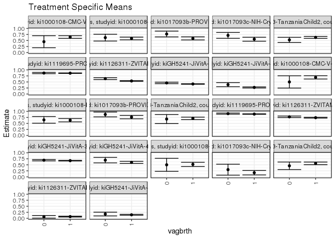

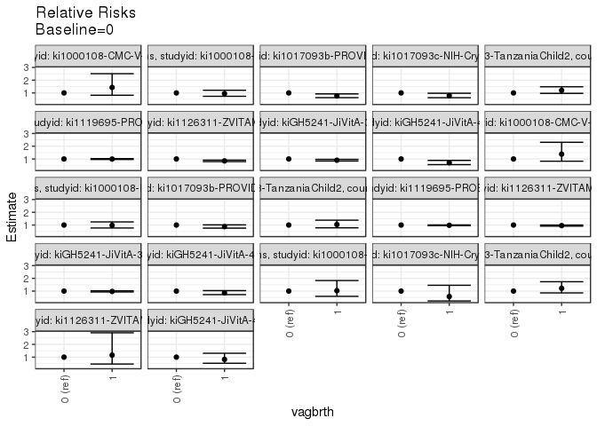

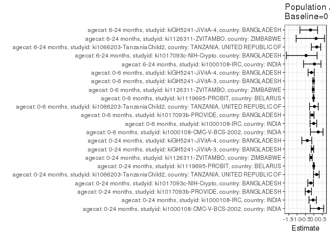

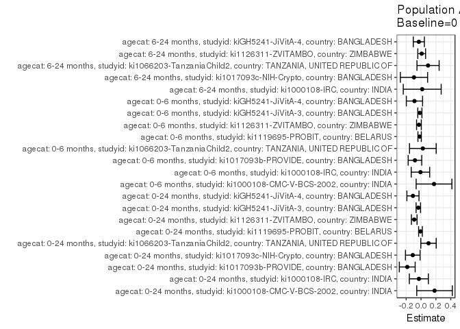

## Results Table

### Parameter: TSM

| agecat | studyid | country | intervention_level | baseline_level | estimate | ci_lower | ci_upper |
| --- | --- | --- | --- | --- | --- | --- | --- |
| 0-24 months | ki1000108-CMC-V-BCS-2002 | INDIA | 0 | NA | 0.4500000 | 0.2006580 | 0.6993420 |
| 0-24 months | ki1000108-CMC-V-BCS-2002 | INDIA | 1 | NA | 0.6437908 | 0.5870303 | 0.7005514 |
| 0-24 months | ki1000108-IRC | INDIA | 0 | NA | 0.6190775 | 0.4773295 | 0.7608255 |
| 0-24 months | ki1000108-IRC | INDIA | 1 | NA | 0.5843315 | 0.5284031 | 0.6402600 |
| 0-24 months | ki1017093b-PROVIDE | BANGLADESH | 0 | NA | 0.7683787 | 0.6472900 | 0.8894673 |
| 0-24 months | ki1017093b-PROVIDE | BANGLADESH | 1 | NA | 0.5860307 | 0.5222840 | 0.6497773 |
| 0-24 months | ki1017093c-NIH-Crypto | BANGLADESH | 0 | NA | 0.7111012 | 0.5898039 | 0.8323986 |
| 0-24 months | ki1017093c-NIH-Crypto | BANGLADESH | 1 | NA | 0.5541648 | 0.4715431 | 0.6367865 |
| 0-24 months | ki1066203-TanzaniaChild2 | TANZANIA, UNITED REPUBLIC OF | 0 | NA | 0.5247804 | 0.4164641 | 0.6330967 |
| 0-24 months | ki1066203-TanzaniaChild2 | TANZANIA, UNITED REPUBLIC OF | 1 | NA | 0.6281103 | 0.5890544 | 0.6671662 |
| 0-24 months | ki1119695-PROBIT | BELARUS | 0 | NA | 0.8686169 | 0.8422311 | 0.8950028 |
| 0-24 months | ki1119695-PROBIT | BELARUS | 1 | NA | 0.8634857 | 0.8529142 | 0.8740571 |
| 0-24 months | ki1126311-ZVITAMBO | ZIMBABWE | 0 | NA | 0.6362701 | 0.5971970 | 0.6753433 |
| 0-24 months | ki1126311-ZVITAMBO | ZIMBABWE | 1 | NA | 0.5399142 | 0.5227609 | 0.5570675 |
| 0-24 months | kiGH5241-JiVitA-3 | BANGLADESH | 0 | NA | 0.4591034 | 0.4287728 | 0.4894340 |
| 0-24 months | kiGH5241-JiVitA-3 | BANGLADESH | 1 | NA | 0.4151486 | 0.4037966 | 0.4265006 |
| 0-24 months | kiGH5241-JiVitA-4 | BANGLADESH | 0 | NA | 0.3869893 | 0.3018363 | 0.4721423 |
| 0-24 months | kiGH5241-JiVitA-4 | BANGLADESH | 1 | NA | 0.2719770 | 0.2499635 | 0.2939904 |
| 0-6 months | ki1000108-CMC-V-BCS-2002 | INDIA | 0 | NA | 0.5000000 | 0.2472620 | 0.7527380 |
| 0-6 months | ki1000108-CMC-V-BCS-2002 | INDIA | 1 | NA | 0.6898396 | 0.6225361 | 0.7571431 |
| 0-6 months | ki1000108-IRC | INDIA | 0 | NA | 0.6450716 | 0.5063712 | 0.7837721 |
| 0-6 months | ki1000108-IRC | INDIA | 1 | NA | 0.6316154 | 0.5621443 | 0.7010865 |
| 0-6 months | ki1017093b-PROVIDE | BANGLADESH | 0 | NA | 0.8695652 | 0.7703543 | 0.9687761 |
| 0-6 months | ki1017093b-PROVIDE | BANGLADESH | 1 | NA | 0.7608696 | 0.6908322 | 0.8309069 |
| 0-6 months | ki1066203-TanzaniaChild2 | TANZANIA, UNITED REPUBLIC OF | 0 | NA | 0.6800000 | 0.4929570 | 0.8670430 |
| 0-6 months | ki1066203-TanzaniaChild2 | TANZANIA, UNITED REPUBLIC OF | 1 | NA | 0.7064516 | 0.6550297 | 0.7578735 |
| 0-6 months | ki1119695-PROBIT | BELARUS | 0 | NA | 0.9043785 | 0.8803276 | 0.9284293 |
| 0-6 months | ki1119695-PROBIT | BELARUS | 1 | NA | 0.8862850 | 0.8761788 | 0.8963912 |
| 0-6 months | ki1126311-ZVITAMBO | ZIMBABWE | 0 | NA | 0.7711542 | 0.7383306 | 0.8039778 |
| 0-6 months | ki1126311-ZVITAMBO | ZIMBABWE | 1 | NA | 0.7363193 | 0.7185593 | 0.7540794 |
| 0-6 months | kiGH5241-JiVitA-3 | BANGLADESH | 0 | NA | 0.6909849 | 0.6632345 | 0.7187353 |
| 0-6 months | kiGH5241-JiVitA-3 | BANGLADESH | 1 | NA | 0.6723905 | 0.6586909 | 0.6860902 |
| 0-6 months | kiGH5241-JiVitA-4 | BANGLADESH | 0 | NA | 0.6941848 | 0.5800311 | 0.8083385 |
| 0-6 months | kiGH5241-JiVitA-4 | BANGLADESH | 1 | NA | 0.6006534 | 0.5559550 | 0.6453518 |
| 6-24 months | ki1000108-IRC | INDIA | 0 | NA | 0.5000000 | 0.2294903 | 0.7705097 |
| 6-24 months | ki1000108-IRC | INDIA | 1 | NA | 0.5179856 | 0.4297875 | 0.6061838 |
| 6-24 months | ki1017093c-NIH-Crypto | BANGLADESH | 0 | NA | 0.3000000 | 0.0725547 | 0.5274453 |
| 6-24 months | ki1017093c-NIH-Crypto | BANGLADESH | 1 | NA | 0.1724138 | 0.0793318 | 0.2654957 |
| 6-24 months | ki1066203-TanzaniaChild2 | TANZANIA, UNITED REPUBLIC OF | 0 | NA | 0.4594723 | 0.3031603 | 0.6157844 |
| 6-24 months | ki1066203-TanzaniaChild2 | TANZANIA, UNITED REPUBLIC OF | 1 | NA | 0.5603389 | 0.5059031 | 0.6147748 |
| 6-24 months | ki1126311-ZVITAMBO | ZIMBABWE | 0 | NA | 0.0609756 | 0.0065400 | 0.1154112 |
| 6-24 months | ki1126311-ZVITAMBO | ZIMBABWE | 1 | NA | 0.0706861 | 0.0547411 | 0.0866311 |
| 6-24 months | kiGH5241-JiVitA-4 | BANGLADESH | 0 | NA | 0.1770114 | 0.0993197 | 0.2547030 |
| 6-24 months | kiGH5241-JiVitA-4 | BANGLADESH | 1 | NA | 0.1458392 | 0.1261112 | 0.1655672 |

### Parameter: E(Y)

| agecat | studyid | country | intervention_level | baseline_level | estimate | ci_lower | ci_upper |
| --- | --- | --- | --- | --- | --- | --- | --- |
| 0-24 months | ki1000108-CMC-V-BCS-2002 | INDIA | NA | NA | 0.6319018 | 0.5759256 | 0.6878781 |
| 0-24 months | ki1000108-IRC | INDIA | NA | NA | 0.5898734 | 0.5376978 | 0.6420491 |
| 0-24 months | ki1017093b-PROVIDE | BANGLADESH | NA | NA | 0.5830619 | 0.5262762 | 0.6398476 |
| 0-24 months | ki1017093c-NIH-Crypto | BANGLADESH | NA | NA | 0.6000000 | 0.5288495 | 0.6711505 |
| 0-24 months | ki1066203-TanzaniaChild2 | TANZANIA, UNITED REPUBLIC OF | NA | NA | 0.6255319 | 0.5876598 | 0.6634040 |
| 0-24 months | ki1119695-PROBIT | BELARUS | NA | NA | 0.8612051 | 0.8511051 | 0.8713052 |
| 0-24 months | ki1126311-ZVITAMBO | ZIMBABWE | NA | NA | 0.5447361 | 0.5281997 | 0.5612725 |
| 0-24 months | kiGH5241-JiVitA-3 | BANGLADESH | NA | NA | 0.4228095 | 0.4116714 | 0.4339475 |
| 0-24 months | kiGH5241-JiVitA-4 | BANGLADESH | NA | NA | 0.2781661 | 0.2567200 | 0.2996121 |
| 0-6 months | ki1000108-CMC-V-BCS-2002 | INDIA | NA | NA | 0.6748768 | 0.6092233 | 0.7405304 |
| 0-6 months | ki1000108-IRC | INDIA | NA | NA | 0.6375000 | 0.5751450 | 0.6998550 |
| 0-6 months | ki1017093b-PROVIDE | BANGLADESH | NA | NA | 0.7880435 | 0.7295878 | 0.8464992 |
| 0-6 months | ki1066203-TanzaniaChild2 | TANZANIA, UNITED REPUBLIC OF | NA | NA | 0.7044776 | 0.6548846 | 0.7540707 |
| 0-6 months | ki1119695-PROBIT | BELARUS | NA | NA | 0.8855266 | 0.8758983 | 0.8951550 |
| 0-6 months | ki1126311-ZVITAMBO | ZIMBABWE | NA | NA | 0.7430972 | 0.7259776 | 0.7602169 |
| 0-6 months | kiGH5241-JiVitA-3 | BANGLADESH | NA | NA | 0.6752697 | 0.6619203 | 0.6886192 |
| 0-6 months | kiGH5241-JiVitA-4 | BANGLADESH | NA | NA | 0.6058824 | 0.5634305 | 0.6483342 |
| 6-24 months | ki1000108-IRC | INDIA | NA | NA | 0.5161290 | 0.4322562 | 0.6000019 |
| 6-24 months | ki1017093c-NIH-Crypto | BANGLADESH | NA | NA | 0.2051282 | 0.1132549 | 0.2970015 |
| 6-24 months | ki1066203-TanzaniaChild2 | TANZANIA, UNITED REPUBLIC OF | NA | NA | 0.5540541 | 0.5015831 | 0.6065250 |
| 6-24 months | ki1126311-ZVITAMBO | ZIMBABWE | NA | NA | 0.0699234 | 0.0546210 | 0.0852257 |
| 6-24 months | kiGH5241-JiVitA-4 | BANGLADESH | NA | NA | 0.1474384 | 0.1282205 | 0.1666563 |

### Parameter: RR

| agecat | studyid | country | intervention_level | baseline_level | estimate | ci_lower | ci_upper |
| --- | --- | --- | --- | --- | --- | --- | --- |
| 0-24 months | ki1000108-CMC-V-BCS-2002 | INDIA | 0 | 0 | 1.0000000 | 1.0000000 | 1.0000000 |
| 0-24 months | ki1000108-CMC-V-BCS-2002 | INDIA | 1 | 0 | 1.4306463 | 0.8163766 | 2.5071137 |
| 0-24 months | ki1000108-IRC | INDIA | 0 | 0 | 1.0000000 | 1.0000000 | 1.0000000 |
| 0-24 months | ki1000108-IRC | INDIA | 1 | 0 | 0.9438746 | 0.7364395 | 1.2097386 |
| 0-24 months | ki1017093b-PROVIDE | BANGLADESH | 0 | 0 | 1.0000000 | 1.0000000 | 1.0000000 |
| 0-24 months | ki1017093b-PROVIDE | BANGLADESH | 1 | 0 | 0.7626847 | 0.6295576 | 0.9239632 |
| 0-24 months | ki1017093c-NIH-Crypto | BANGLADESH | 0 | 0 | 1.0000000 | 1.0000000 | 1.0000000 |
| 0-24 months | ki1017093c-NIH-Crypto | BANGLADESH | 1 | 0 | 0.7793051 | 0.6232224 | 0.9744778 |
| 0-24 months | ki1066203-TanzaniaChild2 | TANZANIA, UNITED REPUBLIC OF | 0 | 0 | 1.0000000 | 1.0000000 | 1.0000000 |
| 0-24 months | ki1066203-TanzaniaChild2 | TANZANIA, UNITED REPUBLIC OF | 1 | 0 | 1.1969013 | 0.9655340 | 1.4837103 |
| 0-24 months | ki1119695-PROBIT | BELARUS | 0 | 0 | 1.0000000 | 1.0000000 | 1.0000000 |
| 0-24 months | ki1119695-PROBIT | BELARUS | 1 | 0 | 0.9940926 | 0.9622737 | 1.0269637 |
| 0-24 months | ki1126311-ZVITAMBO | ZIMBABWE | 0 | 0 | 1.0000000 | 1.0000000 | 1.0000000 |
| 0-24 months | ki1126311-ZVITAMBO | ZIMBABWE | 1 | 0 | 0.8485613 | 0.7923983 | 0.9087049 |
| 0-24 months | kiGH5241-JiVitA-3 | BANGLADESH | 0 | 0 | 1.0000000 | 1.0000000 | 1.0000000 |
| 0-24 months | kiGH5241-JiVitA-3 | BANGLADESH | 1 | 0 | 0.9042595 | 0.8421250 | 0.9709784 |
| 0-24 months | kiGH5241-JiVitA-4 | BANGLADESH | 0 | 0 | 1.0000000 | 1.0000000 | 1.0000000 |
| 0-24 months | kiGH5241-JiVitA-4 | BANGLADESH | 1 | 0 | 0.7028023 | 0.5559025 | 0.8885210 |
| 0-6 months | ki1000108-CMC-V-BCS-2002 | INDIA | 0 | 0 | 1.0000000 | 1.0000000 | 1.0000000 |
| 0-6 months | ki1000108-CMC-V-BCS-2002 | INDIA | 1 | 0 | 1.3796791 | 0.8245122 | 2.3086554 |
| 0-6 months | ki1000108-IRC | INDIA | 0 | 0 | 1.0000000 | 1.0000000 | 1.0000000 |
| 0-6 months | ki1000108-IRC | INDIA | 1 | 0 | 0.9791400 | 0.7691642 | 1.2464375 |
| 0-6 months | ki1017093b-PROVIDE | BANGLADESH | 0 | 0 | 1.0000000 | 1.0000000 | 1.0000000 |
| 0-6 months | ki1017093b-PROVIDE | BANGLADESH | 1 | 0 | 0.8750000 | 0.7556881 | 1.0131495 |
| 0-6 months | ki1066203-TanzaniaChild2 | TANZANIA, UNITED REPUBLIC OF | 0 | 0 | 1.0000000 | 1.0000000 | 1.0000000 |
| 0-6 months | ki1066203-TanzaniaChild2 | TANZANIA, UNITED REPUBLIC OF | 1 | 0 | 1.0388994 | 0.7816335 | 1.3808416 |
| 0-6 months | ki1119695-PROBIT | BELARUS | 0 | 0 | 1.0000000 | 1.0000000 | 1.0000000 |
| 0-6 months | ki1119695-PROBIT | BELARUS | 1 | 0 | 0.9799935 | 0.9522076 | 1.0085902 |
| 0-6 months | ki1126311-ZVITAMBO | ZIMBABWE | 0 | 0 | 1.0000000 | 1.0000000 | 1.0000000 |
| 0-6 months | ki1126311-ZVITAMBO | ZIMBABWE | 1 | 0 | 0.9548276 | 0.9112830 | 1.0004530 |
| 0-6 months | kiGH5241-JiVitA-3 | BANGLADESH | 0 | 0 | 1.0000000 | 1.0000000 | 1.0000000 |
| 0-6 months | kiGH5241-JiVitA-3 | BANGLADESH | 1 | 0 | 0.9730901 | 0.9306827 | 1.0174298 |
| 0-6 months | kiGH5241-JiVitA-4 | BANGLADESH | 0 | 0 | 1.0000000 | 1.0000000 | 1.0000000 |
| 0-6 months | kiGH5241-JiVitA-4 | BANGLADESH | 1 | 0 | 0.8652644 | 0.7223597 | 1.0364399 |
| 6-24 months | ki1000108-IRC | INDIA | 0 | 0 | 1.0000000 | 1.0000000 | 1.0000000 |
| 6-24 months | ki1000108-IRC | INDIA | 1 | 0 | 1.0359712 | 0.5874383 | 1.8269773 |
| 6-24 months | ki1017093c-NIH-Crypto | BANGLADESH | 0 | 0 | 1.0000000 | 1.0000000 | 1.0000000 |
| 6-24 months | ki1017093c-NIH-Crypto | BANGLADESH | 1 | 0 | 0.5747126 | 0.2266054 | 1.4575764 |
| 6-24 months | ki1066203-TanzaniaChild2 | TANZANIA, UNITED REPUBLIC OF | 0 | 0 | 1.0000000 | 1.0000000 | 1.0000000 |
| 6-24 months | ki1066203-TanzaniaChild2 | TANZANIA, UNITED REPUBLIC OF | 1 | 0 | 1.2195271 | 0.8573885 | 1.7346237 |
| 6-24 months | ki1126311-ZVITAMBO | ZIMBABWE | 0 | 0 | 1.0000000 | 1.0000000 | 1.0000000 |
| 6-24 months | ki1126311-ZVITAMBO | ZIMBABWE | 1 | 0 | 1.1592516 | 0.4616155 | 2.9112199 |
| 6-24 months | kiGH5241-JiVitA-4 | BANGLADESH | 0 | 0 | 1.0000000 | 1.0000000 | 1.0000000 |
| 6-24 months | kiGH5241-JiVitA-4 | BANGLADESH | 1 | 0 | 0.8238976 | 0.5204739 | 1.3042101 |

### Parameter: PAR

| agecat | studyid | country | intervention_level | baseline_level | estimate | ci_lower | ci_upper |
| --- | --- | --- | --- | --- | --- | --- | --- |
| 0-24 months | ki1000108-CMC-V-BCS-2002 | INDIA | 0 | NA | 0.1819018 | -0.0576922 | 0.4214959 |
| 0-24 months | ki1000108-IRC | INDIA | 0 | NA | -0.0292041 | -0.1572861 | 0.0988780 |
| 0-24 months | ki1017093b-PROVIDE | BANGLADESH | 0 | NA | -0.1853168 | -0.2916471 | -0.0789865 |
| 0-24 months | ki1017093c-NIH-Crypto | BANGLADESH | 0 | NA | -0.1111012 | -0.2093608 | -0.0128417 |
| 0-24 months | ki1066203-TanzaniaChild2 | TANZANIA, UNITED REPUBLIC OF | 0 | NA | 0.1007515 | -0.0028579 | 0.2043609 |
| 0-24 months | ki1119695-PROBIT | BELARUS | 0 | NA | -0.0074118 | -0.0323983 | 0.0175747 |
| 0-24 months | ki1126311-ZVITAMBO | ZIMBABWE | 0 | NA | -0.0915340 | -0.1294977 | -0.0535703 |
| 0-24 months | kiGH5241-JiVitA-3 | BANGLADESH | 0 | NA | -0.0362939 | -0.0662912 | -0.0062966 |
| 0-24 months | kiGH5241-JiVitA-4 | BANGLADESH | 0 | NA | -0.1088232 | -0.1901593 | -0.0274871 |
| 0-6 months | ki1000108-CMC-V-BCS-2002 | INDIA | 0 | NA | 0.1748768 | -0.0657175 | 0.4154712 |
| 0-6 months | ki1000108-IRC | INDIA | 0 | NA | -0.0075716 | -0.1319318 | 0.1167886 |
| 0-6 months | ki1017093b-PROVIDE | BANGLADESH | 0 | NA | -0.0815217 | -0.1728369 | 0.0097935 |
| 0-6 months | ki1066203-TanzaniaChild2 | TANZANIA, UNITED REPUBLIC OF | 0 | NA | 0.0244776 | -0.1550298 | 0.2039850 |
| 0-6 months | ki1119695-PROBIT | BELARUS | 0 | NA | -0.0188518 | -0.0417787 | 0.0040750 |
| 0-6 months | ki1126311-ZVITAMBO | ZIMBABWE | 0 | NA | -0.0280569 | -0.0599755 | 0.0038616 |
| 0-6 months | kiGH5241-JiVitA-3 | BANGLADESH | 0 | NA | -0.0157152 | -0.0437826 | 0.0123522 |
| 0-6 months | kiGH5241-JiVitA-4 | BANGLADESH | 0 | NA | -0.0883024 | -0.1979176 | 0.0213127 |
| 6-24 months | ki1000108-IRC | INDIA | 0 | NA | 0.0161290 | -0.2390237 | 0.2712818 |
| 6-24 months | ki1017093c-NIH-Crypto | BANGLADESH | 0 | NA | -0.0948718 | -0.2780930 | 0.0883494 |
| 6-24 months | ki1066203-TanzaniaChild2 | TANZANIA, UNITED REPUBLIC OF | 0 | NA | 0.0945817 | -0.0546223 | 0.2437858 |
| 6-24 months | ki1126311-ZVITAMBO | ZIMBABWE | 0 | NA | 0.0089478 | -0.0433206 | 0.0612162 |
| 6-24 months | kiGH5241-JiVitA-4 | BANGLADESH | 0 | NA | -0.0295730 | -0.1043232 | 0.0451773 |

### Parameter: PAF

| agecat | studyid | country | intervention_level | baseline_level | estimate | ci_lower | ci_upper |
| --- | --- | --- | --- | --- | --- | --- | --- |
| 0-24 months | ki1000108-CMC-V-BCS-2002 | INDIA | 0 | NA | 0.2878641 | -0.2169136 | 0.5832592 |
| 0-24 months | ki1000108-IRC | INDIA | 0 | NA | -0.0495090 | -0.2904034 | 0.1464148 |
| 0-24 months | ki1017093b-PROVIDE | BANGLADESH | 0 | NA | -0.3178338 | -0.5160353 | -0.1455446 |
| 0-24 months | ki1017093c-NIH-Crypto | BANGLADESH | 0 | NA | -0.1851687 | -0.3624803 | -0.0309323 |
| 0-24 months | ki1066203-TanzaniaChild2 | TANZANIA, UNITED REPUBLIC OF | 0 | NA | 0.1610654 | -0.0217393 | 0.3111635 |
| 0-24 months | ki1119695-PROBIT | BELARUS | 0 | NA | -0.0086063 | -0.0380474 | 0.0199998 |
| 0-24 months | ki1126311-ZVITAMBO | ZIMBABWE | 0 | NA | -0.1680337 | -0.2408492 | -0.0994913 |
| 0-24 months | kiGH5241-JiVitA-3 | BANGLADESH | 0 | NA | -0.0858399 | -0.1595696 | -0.0167982 |
| 0-24 months | kiGH5241-JiVitA-4 | BANGLADESH | 0 | NA | -0.3912168 | -0.7166638 | -0.1274684 |
| 0-6 months | ki1000108-CMC-V-BCS-2002 | INDIA | 0 | NA | 0.2591241 | -0.2023404 | 0.5434761 |
| 0-6 months | ki1000108-IRC | INDIA | 0 | NA | -0.0118771 | -0.2270393 | 0.1655563 |
| 0-6 months | ki1017093b-PROVIDE | BANGLADESH | 0 | NA | -0.1034483 | -0.2274251 | 0.0080062 |
| 0-6 months | ki1066203-TanzaniaChild2 | TANZANIA, UNITED REPUBLIC OF | 0 | NA | 0.0347458 | -0.2569309 | 0.2587375 |
| 0-6 months | ki1119695-PROBIT | BELARUS | 0 | NA | -0.0212888 | -0.0475329 | 0.0042977 |
| 0-6 months | ki1126311-ZVITAMBO | ZIMBABWE | 0 | NA | -0.0377568 | -0.0818148 | 0.0045070 |
| 0-6 months | kiGH5241-JiVitA-3 | BANGLADESH | 0 | NA | -0.0232724 | -0.0658206 | 0.0175772 |
| 0-6 months | kiGH5241-JiVitA-4 | BANGLADESH | 0 | NA | -0.1457419 | -0.3430711 | 0.0225949 |
| 6-24 months | ki1000108-IRC | INDIA | 0 | NA | 0.0312500 | -0.6139924 | 0.4185372 |
| 6-24 months | ki1017093c-NIH-Crypto | BANGLADESH | 0 | NA | -0.4625000 | -1.6271554 | 0.1858471 |
| 6-24 months | ki1066203-TanzaniaChild2 | TANZANIA, UNITED REPUBLIC OF | 0 | NA | 0.1707085 | -0.1472946 | 0.4005686 |
| 6-24 months | ki1126311-ZVITAMBO | ZIMBABWE | 0 | NA | 0.1279653 | -1.0561158 | 0.6301548 |
| 6-24 months | kiGH5241-JiVitA-4 | BANGLADESH | 0 | NA | -0.2005783 | -0.8313552 | 0.2129389 |